# Exploratory Data Analysis

Panayiotis L.

9/29/2020

## Load libraries

```r
library(tidyr)
library(dplyr)
library(utils)
library(downloader)
library(plyr)
library(knitr)
library(tm)
library(stringi)
library(RWeka)
library(ggplot2)
```

## Summary

This is the Milestone Report for the Data Science Capstone project. The goal of the capstone project is to create a predictive text model using a large text corpus of documents. Natural language processing techniques will be used to perform the analysis and build the predictive model.

This milestone report describes the major features of the training data with our exploratory data analysis and summarizes our plans for creating the predictive model.

## Set paths to the three en_US datasets

```r
path_to_blogs <- "./data/final/en_US/en_US.blogs.txt"
path_to_news <- "./data/final/en_US/en_US.news.txt"
path_to_twitter <- "./data/final/en_US/en_US.twitter.txt"
```

## Download and extract the data

The data sets includes text from 3 different sources: 1) News, 2) Blogs and 3) Twitter feeds. In this project, we will only focus on the English - US data sets.

```r
# If all files already exist do not download them
if (!file.exists(path_to_blogs) | !file.exists(path_to_news) | !file.exists(path_to_twitter)){
    data_url <- "https://d396qusza40orc.cloudfront.net/dsscapstone/dataset/Coursera-SwiftKey.zip"
    zip_name <- "Coursera-SwiftKey.zip"
    if(!file.exists(zip_name)){
        download.file(data_url, method="curl", destfile=zip_name)
    }
    unzip(zip_name, exdir="./data")
    file.remove(zip_name)
}
```

## Loading the Data

```r
con <- file(path_to_twitter, "r")
twitter_lines <- readLines(con, skipNul = TRUE)
# Close the file connection
close(con)

con <- file(path_to_blogs, "r")
blog_lines <- readLines(con, skipNul = TRUE)
# Close the file connection
close(con)

con <- file(path_to_news, "r")
news_lines <- readLines(con, skipNul = TRUE)
# Close the file connection
close(con)
```

Below you can find a summary of the data sets, like file sizes, line counts, word counts and mean words per line.

```r
# Get file sizes
blog_lines.size <- file.info(path_to_blogs)$size / 1024 ^ 2
news_lines.size <- file.info(path_to_news)$size / 1024 ^ 2
twitter_lines.size <- file.info(path_to_twitter)$size / 1024 ^ 2
# Get words in files
blog_lines.words <- stri_count_words(blog_lines)
news_lines.words <- stri_count_words(news_lines)
twitter_lines.words <- stri_count_words(twitter_lines)
# Summary of the data sets
data.frame(source = c("blogs", "news", "twitter"),
           file.size.MB = c(blog_lines.size, news_lines.size, twitter_lines.size),
           num.lines = c(length(blog_lines), length(news_lines), length(twitter_lines)),
           num.words = c(sum(blog_lines.words), sum(news_lines.words), sum(twitter_lines.words)),
           mean.num.words = c(mean(blog_lines.words), mean(news_lines.words), mean(twitter_lines.words)))
```

```
##    source file.size.MB num.lines num.words mean.num.words
## 1   blogs     200.4242    899288  37546239       41.75107
## 2    news     196.2775   1010242  34762395       34.40997
## 3 twitter     159.3641   2360148  30093413       12.75065
```

## Data Cleaning

Before performing exploratory data analysis, we must first clean the data. This involves removing URLs, special characters, punctuations, numbers, excess whitespace, stopwords, and changing the text to lower case. Since the data sets are quite large, we will randomly choose 2% of the data to demonstrate the data cleaning and exploratory analysis also please take care of the UTF chars.

```r
# Sample the data
set.seed(5000)
data.sample <- c(sample(blog_lines, length(blog_lines) * 0.02),
                 sample(news_lines, length(news_lines) * 0.02),
                 sample(twitter_lines, length(twitter_lines) * 0.02))
# Create corpus and clean the data
corpus <- VCorpus(VectorSource(data.sample))
toSpace <- content_transformer(function(x, pattern) gsub(pattern, " ", x))
corpus <- tm_map(corpus, toSpace, "(f|ht)tp(s?)://(.*)[.][a-z]+")
corpus <- tm_map(corpus, toSpace, "@[^\\s]+")
corpus <- tm_map(corpus, tolower)
corpus <- tm_map(corpus, removeWords, stopwords("en"))
corpus <- tm_map(corpus, removePunctuation)
corpus <- tm_map(corpus, removeNumbers)
corpus <- tm_map(corpus, stripWhitespace)
corpus <- tm_map(corpus, PlainTextDocument)

remove(blog_lines)
remove(news_lines)
remove(twitter_lines)
```

## Exploratory Data Analysis (EDA)

Now it’s time to do some exploratory data analysis. It would be interesting to find the most frequently occurring words in the data. Here we list the most common (n-grams) uni-grams, bi-grams, and tri-grams.

```r
##annotate
options(mc.cores=1)
# we'll get the frequencies of the word
getFreq <- function(tdm) {
  freq <- sort(rowSums(as.matrix(tdm)), decreasing = TRUE)
  return(data.frame(word = names(freq), freq = freq))
}
bigram <- function(x) NGramTokenizer(x, Weka_control(min = 2, max = 2))
trigram <- function(x) NGramTokenizer(x, Weka_control(min = 3, max = 3))
makePlot <- function(data, label) {
    ggplot(data[1:30,], aes(reorder(word, -freq), freq)) +
         labs(x = label, y = "Frequency") +
         theme(axis.text.x = element_text(angle = 60, size = 12, hjust = 1)) +
         geom_bar(stat = "identity", fill = I("green"))
}
# Get frequencies of most common n-grams in data sample
freq1 <- getFreq(removeSparseTerms(TermDocumentMatrix(corpus), 0.9999))
freq2 <- getFreq(removeSparseTerms(TermDocumentMatrix(corpus, control = list(tokenize = bigram)), 0.9999))
freq3 <- getFreq(removeSparseTerms(TermDocumentMatrix(corpus, control = list(tokenize = trigram)), 0.9999))
```

The histogram below shows the 30 most common unigrams in the data sample.

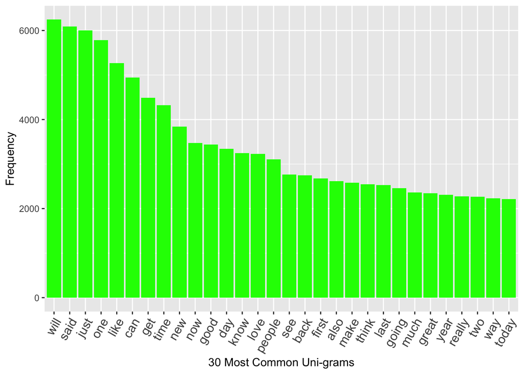

```r
makePlot(freq1, "30 Most Common Uni-grams")
```

This histogram illustrates the 30 most common bigrams in the data sample.

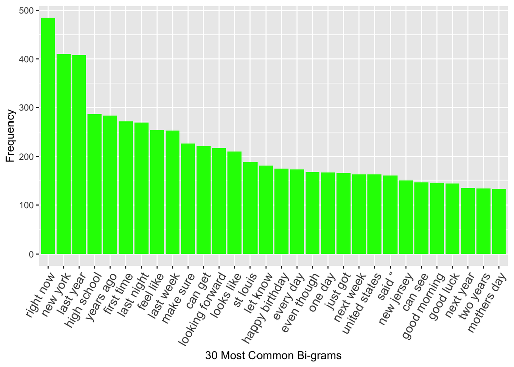

```r
makePlot(freq2, "30 Most Common Bi-grams")
```

This histogram displays the 30 most common trigrams in the data sample.

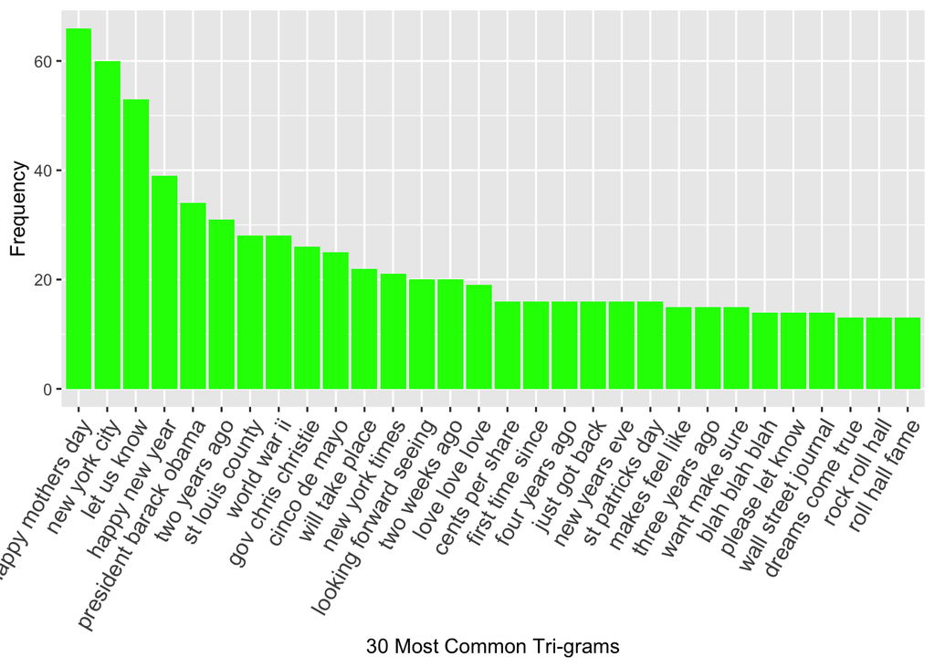

```r
makePlot(freq3, "30 Most Common Tri-grams")
```

## Conclusion

This concludes our EDA. The next steps of this capstone project are to finalize the predictive algorithm and deploy the algorithm as a Shiny app.

Our predictive algorithm will be using n-gram models with frequency lookup like the above exploratory data analysis. A promising strategy would be to use a tri-gram model to predict the next word. If tri-gram fails to find a match, then the algorithm will use the bi-gram model, and then to the uni-gram model, if needed.

The user interface for the Shiny app will include a text box that will allow the user to enter a phrase. Then the app will use the predictive algorithm to suggest the next word that is more likely to appear.